# Сообщество фитопланктона Обской губы

# Связь сообщества фитопланктона с параметрами среды

При рассмотрении всего сообщества фитопланктона, включающего 193 вида, был проведен канонический корреспонтдентный анализ (ССА). В анализе данные по отдельным горизонтам глубины (поверхностный, средний и придонный) были объединены, обилие отдельных видов было усреднено. В качестве предикторов в анализ на первом его этапе были включены следующие переменные :Color, O2, pH, Amon_N, Nitrit_N, Nitrat_N, Total_N, Mineral_P, Total_P, Si, Organic_N, Organic_P, Depth, Transparency, Surf_Salinity, Bot_Salinity, Surf_Turbidity, Bot_Turbidity (см. Табл. S1 в приложении). Результаты анализа демонстрирует Рисунок 1.

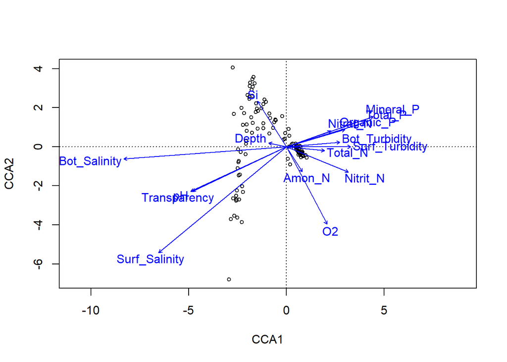

**Рисунок 1.** Ординация проб в первой и второй канонических корреспондентных осях, описывающих связи сообщества фитопланктона с парамтерами среды

Для выявления наиболее значимых предикторов был проведен подбор оптимальной модели в соответствии с алгоритмом прямого пошагового подбора (forward selection). В результате анализа была получена сокращенная модель CCA (Рисунок 2), которая включала всего три ключевых параметра среды: соленость (поверхностная и придонная) и концентрация кислорода. Все упомянутые предикторы оказывали статистически значимое воздействие на ординацию. Первая каноническая ось, описывающая 15.7% общей изменчивости, связана с соленостью. Вторую каноническую ось, описывающую лишь 2.5% общей изменчивости, можно отчасти связать с концентрацией растворенного кислорода.

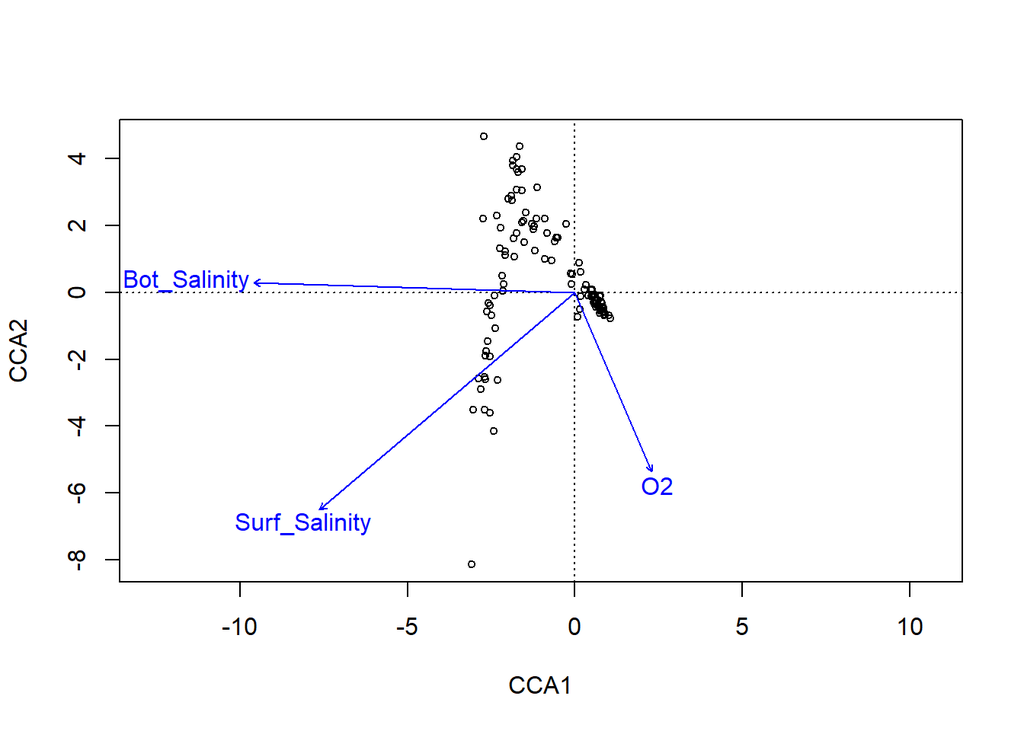

**Рисунок 2.** Ординация проб в первой и второй канонических корреспондентных осях (сокращенная модель), описывающих связи сообщества фитопланктона с параметрами среды

Таким образом, сообщество фитопланктона, в изученных масштабах, находится в основном под контролем морских вод. Градиент ССA1 отражает как видовое разнообразие, падающее по мере увеличения значений ССA1 (Рисунок 3, A), так и обилие фитопланктона (суммарная численность всех видов), которое возрастает по мере увеличения значений CCA1 (Рисунок 3, B). Соленость придонной и поверхностной водной массы падает по мере увеличения значений CCA1 (Рисунок 3, C, D).

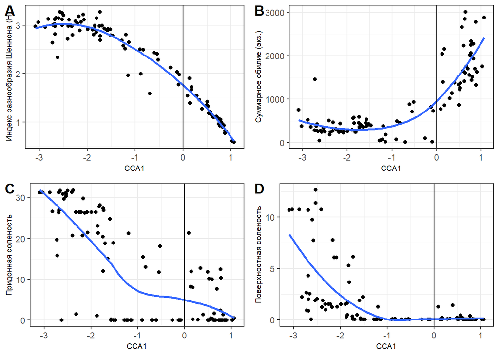

**Рисунок 3.** Связь значений CCA1 c видовым разнообразием сообщества фитопланктона и значениями придонной и повперхностной солености. Приведены LOESS-линии регрессии.

В пространстве сообщество фитопланктона демонстрирует градиент очень близкий к градиенту солености (Рисунок 4). Таким образом, наиболее разнообразное сообщество фитопланктона представлено в северной части устья Обской губы, которая находится под влиянием морских вод. Менее разнообразное, но при этом, характеризующееся очень высоким суммарным обилием, сообщество фитопланктона представлено в южной, наиболее опресненной части акватории.

Для дальнейшего анализа все станции были разбиты на две условные группы в соответствии с величиной значений первой канонической оси. К первой группе, условно обозначаемой, как сообщество фитопланктона, представленного в осолоненной водной массе (“Saline”), были отнесены следующие станции: O1, O10, O101, O102, O104, O105, O107, O108, O109, O11, O111, O112, O12, O13, O14, O15, O16, O18, O19, O2, O21, O22, O24, O25, O27, O29, O3, O30, O31, O32, O33, O34, O35, O36, O37, O38, O39, O4, O40, O41, O42, O43, O44, O45, O46, O47, O48, O49, O5, O53, O54, O55, O56, O6, O60, O61, O62, O67, O7, O70, O79, O8, O86, O89, O9, O99. Ко второй группе (“Fresh”) были отнесены станции: O28, O50, O51, O52, O57, O58, O59, O63, O64, O65, O66, O68, O69, O71, O72, O73, O74, O75, O76, O77, O78, O80, O81, O82, O83, O84, O85, O87, O88, O90, O91, O92, O93, O94, O95, O96, O97, O98. Пространственное распределение станций двух разных групп приведено на Рисунок 4. Параметры водной среды в станциях, отнесенных к двум разным группам, приведены в таблице S2 в приложении.

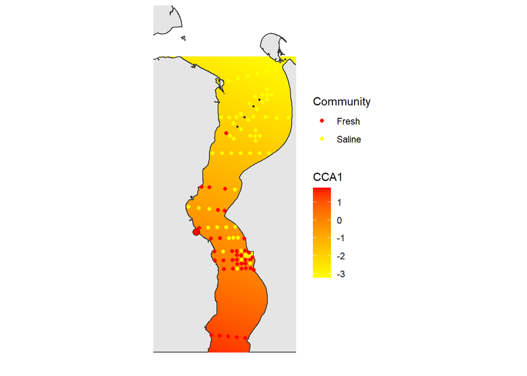

**Рисунок 4.** Распределение значений первой канонической оси, характериюзующей структуру сообщества фитопланктона

# Связь сообщества фитопланктона с уровнем взвеси

Для анализа связи структуры сообщества фитопланктона с уровнем содержания в воде взвешенный частиц были построены две регрессионные модели. В качестве переменной отклика в первой модели выступала величина коэффициента Шеннона (*H*), описывающая видовое разнообразие сообщества, а во второй - общая численность фитопланктона (*Total_N*). В обеих моделях в качестве предикторов выступали тип сообщества (дискретный фактор с двумя градациями: *Saline* vs *Fresh*), количество взвешенных частиц (*Suspended_matter*) и взаимодействие этих предикторов. В модель также был включен компонент, описывающий пространственную автокорреляцию остатков (Exponential correlation structure).

Обе подобранные модели включали статистически значимое взаимодействие предикторов (Табл. 1, 2). Поскольку на фоне значимого взаимодействия анализ главных эффектов невозможен, были построены графики, визуализирующие характер связей, описываемых моделями (Рисунок 5). Оба показателя не демонстрировали значимой связи с концентрацией взвешенных веществ в пресноводных сообществах фитопланктона. Однако в случае сообщества фитопланктона, представленного в осолоненных водных массах, и видовое разнообразие, и общая численность резко снижаются по мере увеличения концентрации взвеси.

Таким образом, повышенная концентрация взвешенных частиц, которые потенциально имеют техногенное происхождение, приводит к снижению биоразнообразия и общего обилия фитопланктона только в осолоненной водной массе. Сообщество представленное в опресненной водной массе не демонстрирует зависимости от концентрации взвешенных частиц.

Таблица 1. Параметры регрессионной модели, описывающей зависимость видового разнообразия фитопланктона от типа сообщества и концентрации взвешенных веществ

| term | estimate | std.error | statistic | p.value |
| --- | --- | --- | --- | --- |
| (Intercept) | 1.1547 | 0.0819 | 14.0973 | 0.0000 |
| CommunitySaline | 1.8402 | 0.0991 | 18.5743 | 0.0000 |
| Suspended_matter | 0.0000 | 0.0012 | 0.0194 | 0.9845 |
| CommunitySaline:Suspended_matter | -0.0036 | 0.0014 | -2.5200 | 0.0133 |

Таблица 2. Параметры регрессионной модели, описывающей зависимость общего обилия фитопланктона от типа сообщества и концентрации взвешенных веществ

| term | estimate | std.error | statistic | p.value |
| --- | --- | --- | --- | --- |
| (Intercept) | 7.4066 | 0.1515 | 48.9017 | 0.0000 |
| CommunitySaline | -1.2125 | 0.1834 | -6.6098 | 0.0000 |
| Suspended_matter | 0.0004 | 0.0022 | 0.1875 | 0.8516 |
| CommunitySaline:Suspended_matter | -0.0102 | 0.0027 | -3.8520 | 0.0002 |

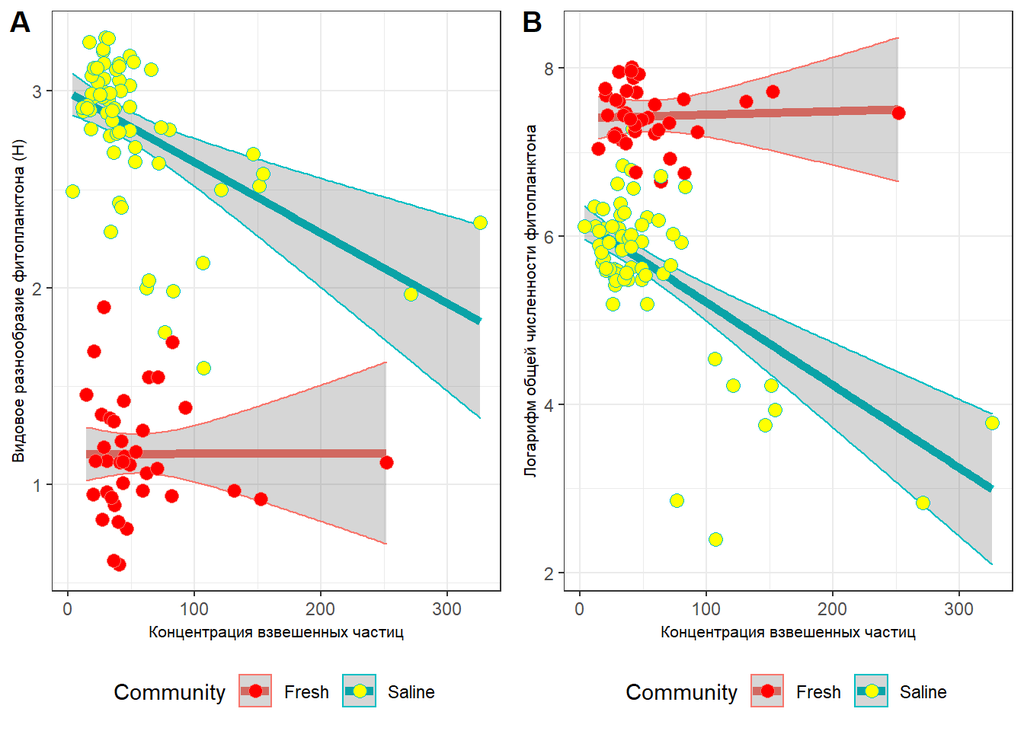

**Рисунок 5.** Зависимость видового разнообразия сообщества фитопланктона (A) и его общего обилия (B) от типа сообщества и концентрации взвешенных частиц.

# Приложение

Таблица S1. Обозначения переменных

| **Переменная** | **Содержание** |
| --- | --- |
| Station | Станция |
| Lat | Широта (N) |
| Long | Долгота (E) |
| Depth | Глубина по эхолоту, м |
| Transparency | Прозрачность, м |
| Surf_Salinity | Соленость_пов [psu] |
| Bot_Salinity | Соленость_дно [psu] |
| Surf_Turbidity | Мутность_пов [NTU] |
| Bot_Turbidity | Мутность_дно [NTU] |
| Surf_Susp | Взвешенные вещества, мг/л поверхностный слой |
| Interm_Susp | Взвешенные вещества, мг/л промежуточный слой |
| Bot_Susp | Взвешенные вещества, мг/л придонный слой |
| Chla_surface | Концентрация хлорофилла а (мкг/л) в поверхностно слое |
| Chla_intermed | Концентрация хлорофилла а (мкг/л) в промежуточном слое |
| Chla_bottom | Концентрация хлорофилла а (мкг/л) в придонном слое |
| Org | Концентрация органического вещества в грунте (%) |
| Fine_particles | Доля мелкой фракции грунта (диаметр меньше 0.05 мм) |
| Coarce_particles | Доля крупной фракции грунта (диаметр больше 0.05 мм) |
| Bot_Color | Цветность, градус в придонном слое воды |
| Bot_O2 | О2, мгО2/куб. дм в придонном слое воды |
| Bot_pH | рН в придонном слое воды |
| Bot_Amon_N | Азот Аммоний, мкг/л в придонном слое воды |
| Bot_Nitrit_N | Азот нитритный, мкг/л в придонном слое воды |
| Bot_Nitrat_N | Азот нитратный, мкг/л в придонном слое воды |
| Bot_Total_N | Азот общий, мкг/л в придонном слое воды |
| Bot_Mineral_P | Фосфор минеральный мкг/л в придонном слое воды |
| Bot_Total_P | Фосфор общий, мкг/л в придонном слое воды |
| Bot_Si | Кремний, мкг/л в придонном слое воды |
| Bot_Organic_N | Азот органический, мкг/л в придонном слое воды |
| Bot_Organic_P | фосфор органический, мкг/л в придонном слое воды |
| Int_Color | Цветность, градус в промежуточном слое воды |
| Int_O2 | О2, мгО2/куб. дм в промежуточном слое воды |
| Int_pH | рН в промежуточном слое воды |
| Int_Amon_N | Азот Аммоний, мкг/л в промежуточном слое воды |
| Int_Nitrit_N | Азот нитритный, мкг/л в промежуточном слое воды |
| Int_Nitrat_N | Азот нитратный, мкг/л в промежуточном слое воды |
| Int_Total_N | Азот общий, мкг/л в промежуточном слое воды |
| Int_Mineral_P | Фосфор минеральный мкг/л в промежуточном слое воды |
| Int_Total_P | Фосфор общий, мкг/л в промежуточном слое воды |
| Int_Si | Кремний, мкг/л в промежуточном слое воды |
| Int_Organic_N | Азот органический, мкг/л в промежуточном слое воды |
| Int_Organic_P | фосфор органический, мкг/л в промежуточном слое воды |
| Surf_Color | Цветность, градус в поверхностном слое воды |
| Surf_O2 | О2, мгО2/куб. дм в поверхностном слое воды |
| Surf_pH | рН в поверхностном слое воды |
| Surf_Amon_N | Азот Аммоний, мкг/л в поверхностном слое воды |
| Surf_Nitrit_N | Азот нитритный, мкг/л в поверхностном слое воды |
| Surf_Nitrat_N | Азот нитратный, мкг/л в поверхностном слое воды |
| Surf_Total_N | Азот общий, мкг/л в поверхностном слое воды |
| Surf_Mineral_P | Фосфор минеральный мкг/л в поверхностном слое воды |
| Surf_Total_P | Фосфор общий, мкг/л в поверхностном слое воды |
| Surf_Si | Кремний, мкг/л в поверхностном слое воды |
| Surf_Organic_N | Азот органический, мкг/л в поверхностном слое воды |
| Surf_Organic_P | фосфор органический, мкг/л в поверхностном слое воды |
| Ships | Судовая нагрузка |
| Distance_Dump | Расстояние до точек отвала грунта |
| Distance_to_Drag | Расстояние до точек дноуглубления |

Таблица S2. Средние значения и стандартные отклонения параметров водной среды в станциях, отнесенных к двум типам сообществ фитопланктона

| **Переменная** | **Среднее значение в пресноводном сообществе (Fresh)** | **SD Fresh** | **Среднее значение в сообществе осолоненной воды (Saline)** | **SD Saline** |
| --- | --- | --- | --- | --- |
| Depth | 13.26 | 6.58 | 13.52 | 4.31 |
| Transparency | 0.57 | 0.32 | 0.80 | 0.49 |
| Surf_Salinity | 0.16 | 0.30 | 2.63 | 3.63 |
| Bot_Salinity | 3.52 | 5.43 | 17.79 | 12.34 |
| Surf_Turbidity | 88.31 | 23.44 | 80.34 | 23.14 |
| Bot_Turbidity | 104.49 | 19.91 | 98.84 | 20.10 |
| Surf_Susp | 54.93 | 47.28 | 42.35 | 59.92 |
| Interm_Susp | 48.23 | 26.13 | 48.04 | 45.80 |
| Bot_Susp | 53.32 | 43.74 | 58.17 | 41.52 |
| Chla_surface | 4.83 | 2.19 | 2.65 | 2.01 |
| Chla_intermed | 4.12 | 1.93 | 1.92 | 1.23 |
| Chla_bottom | 5.10 | 4.68 | 2.49 | 1.99 |
| Org | 0.17 | 0.09 | 0.21 | 0.10 |
| Fine_particles | 58.53 | 25.58 | 74.25 | 17.88 |
| Coarce_particles | 41.48 | 25.58 | 25.75 | 17.88 |
| Bot_Color | 108.35 | 36.54 | 87.35 | 86.72 |
| Bot_O2 | 10.87 | 1.52 | 9.58 | 1.74 |
| Bot_pH | 7.59 | 0.06 | 7.67 | 0.20 |
| Bot_Amon_N | 4.44 | 8.42 | 17.05 | 32.72 |
| Bot_Nitrit_N | 3.89 | 2.93 | 2.45 | 2.68 |
| Bot_Nitrat_N | 43.76 | 12.94 | 35.80 | 11.05 |
| Bot_Total_N | 99.08 | 29.79 | 101.64 | 61.40 |
| Bot_Mineral_P | 16.28 | 4.97 | 14.28 | 10.47 |
| Bot_Total_P | 93.52 | 15.70 | 81.82 | 28.00 |
| Bot_Si | 681.86 | 169.50 | 728.33 | 195.01 |
| Bot_Organic_N | 46.98 | 23.12 | 46.34 | 30.12 |
| Bot_Organic_P | 77.25 | 15.05 | 67.54 | 20.59 |
| Int_Color | 127.88 | 47.08 | 100.03 | 61.45 |
| Int_O2 | 11.15 | 1.40 | 10.18 | 1.58 |
| Int_pH | 7.58 | 0.08 | 7.65 | 0.17 |
| Int_Amon_N | 18.19 | 13.96 | 21.87 | 33.34 |
| Int_Nitrit_N | 2.53 | 2.24 | 1.62 | 1.64 |
| Int_Nitrat_N | 36.63 | 11.64 | 29.47 | 9.61 |
| Int_Total_N | 93.43 | 26.27 | 92.67 | 43.10 |
| Int_Mineral_P | 17.26 | 3.86 | 14.37 | 8.08 |
| Int_Total_P | 78.47 | 14.93 | 69.44 | 23.67 |
| Int_Si | 504.33 | 158.24 | 548.59 | 194.39 |
| Int_Organic_N | 36.08 | 19.20 | 39.71 | 17.92 |
| Int_Organic_P | 61.21 | 14.11 | 55.07 | 17.62 |
| Surf_Color | 142.11 | 65.38 | 112.58 | 65.59 |
| Surf_O2 | 11.47 | 1.99 | 10.21 | 1.78 |
| Surf_pH | 7.49 | 0.13 | 7.56 | 0.22 |
| Surf_Amon_N | 18.04 | 37.03 | 24.64 | 47.92 |
| Surf_Nitrit_N | 1.86 | 2.29 | 1.09 | 1.68 |
| Surf_Nitrat_N | 31.68 | 7.82 | 29.44 | 9.36 |
| Surf_Total_N | 93.68 | 43.86 | 97.36 | 65.74 |
| Surf_Mineral_P | 17.54 | 6.44 | 14.80 | 10.66 |
| Surf_Total_P | 68.72 | 18.77 | 60.42 | 28.85 |
| Surf_Si | 434.61 | 194.18 | 491.89 | 209.23 |
| Surf_Organic_N | 42.10 | 17.08 | 42.18 | 23.10 |
| Surf_Organic_P | 51.19 | 15.85 | 45.63 | 20.20 |

Таблица S3. Виды фитопланктона, тяготеющие к осолоненным водным массам

| Виды | Группа |
| --- | --- |
| Chrysochromylina sp. | Haptophyta |
| Eutreptiella gymnastica | Euglenophyta |
| Eutreptiella lanowii | Euglenophyta |
| Trachelomonas planctonica | Euglenophyta |
| Trachelomonas regulosa | Euglenophyta |
| Trachelomonas volvocina | Euglenophyta |
| Trachelomonas volvociniopsis | Euglenophyta |
| Alexandrium tamarense | Dinophyta |
| Amphidinium carterae | Dinophyta |
| Amphidinium exentsum | Dinophyta |
| Amphidinium longum | Dinophyta |
| Amphidinium sphenoides | Dinophyta |
| Dinophysis ovum | Dinophyta |
| Dinophysis rotundata | Dinophyta |
| Gymnodinium helveticum | Dinophyta |
| Gymnodinium spp. | Dinophyta |
| Gyrodinium lacryma | Dinophyta |
| Gyrodinium pellucidum | Dinophyta |
| Heterocapsa triquetra | Dinophyta |
| Karlodinium veneficum | Dinophyta |
| Katodinium glaucum | Dinophyta |
| Oxytoxum gladiolus | Dinophyta |
| Oxytoxum scolopax | Dinophyta |
| Peridiniella catenata | Dinophyta |
| Prorocentrum cordatum | Dinophyta |
| Prorocentrum micans | Dinophyta |
| Prorocentrum minimum | Dinophyta |
| Scrippsiella sp. | Dinophyta |
| Scrippsiella trochoidea | Dinophyta |
| Anabaena lemmermanii | Cyanophyta |

[output cut: 127 more lines]

Таблица S4. Виды фитопланктона, тяготеющие к опресненным водным массам

| Виды | Группа |
| --- | --- |
| Trachelomonas acanthostoma | Euglenophyta |
| Trachelomonas hispida | Euglenophyta |
| Gymnodinium arcticum | Dinophyta |
| Heterocapsa rotundata | Dinophyta |
| Aphanizomenon issatchenkovi | Cyanophyta |
| Aphanizomenon sp. | Cyanophyta |
| Chroococcus sp. | Cyanophyta |
| Oscillatoria sp. | Cyanophyta |
| Cryptomonas gracilis | Cryptophyta |
| Cryptomonas rostrata | Cryptophyta |
| Coelastrum astroideum | Chlorophyta |
| Cosmarium phaseolus | Chlorophyta |
| Oocystis submarina | Chlorophyta |
| Pediastrum boryanum v.longicornis | Chlorophyta |
| Scenedesmus denticulatus | Chlorophyta |
| Scenedesmus quadrispina | Chlorophyta |
| Amphiprora ornata | Bacillariophyta |
| Amphora ovalis | Bacillariophyta |
| Aulacoseira islandica | Bacillariophyta |
| Craticula halophila | Bacillariophyta |
| Cymatopleura solea | Bacillariophyta |
| Diploneis interrupta | Bacillariophyta |
| Eunotia sibirica | Bacillariophyta |
| Fragilaria heidenii | Bacillariophyta |
| Fragilaria crotonensis | Bacillariophyta |
| Gyrosigma macrum | Bacillariophyta |
| Nitzschia communis | Bacillariophyta |
| Nitzschia linearis | Bacillariophyta |
| Nitzschia palea | Bacillariophyta |
| Nitzschia seriata | Bacillariophyta |
| Stephanodiscus hantzschii | Bacillariophyta |
| Surirella elegans | Bacillariophyta |
| Surirella ovalis | Bacillariophyta |
| Surirella ovata | Bacillariophyta |
| Surirella spp. | Bacillariophyta |